# Building intuition into popgen fundamentals and inference

### Bonus 5: How many unique f4 quartets are there?

In your lecture about $f$-statistics, you’ve probably learned about various symmetries in $f_4$ (but also other $f$-statistics) depending on the arrangement of the “quartet”. As a trivial example, an $f_3(A; B, C)$ and $f_3(A; C, B)$ will give you exactly the same value, and the same thing applies even to more complex $f$-statistics like $f_4$.

**Use simulations to compute how manu unique** $f_4$ values involving a single quartet are there.

**Hint:** Draw some trees to figure out why could that be true. Also, when computing `ts_f4()`, set `mode = "branch"` to avoid the effect of statistical noise due to mutations.

**Click to see the solution**

```r
# # install a combinatorics R package
# install.packages("combinat")

library(combinat)
# These are the four samples we can create quartet combinations from
quartet <- c("AFR_1", "EUR_1", "NEA_1", "CHIMP_1")
quartets <- permn(quartet)
quartets
```

```
[[1]]
[1] "AFR_1"   "EUR_1"   "NEA_1"   "CHIMP_1"

[[2]]
[1] "AFR_1"   "EUR_1"   "CHIMP_1" "NEA_1"

[[3]]
[1] "AFR_1"   "CHIMP_1" "EUR_1"   "NEA_1"

[[4]]
[1] "CHIMP_1" "AFR_1"   "EUR_1"   "NEA_1"

[[5]]
[1] "CHIMP_1" "AFR_1"   "NEA_1"   "EUR_1"

[[6]]
[1] "AFR_1"   "CHIMP_1" "NEA_1"   "EUR_1"

[[7]]
[1] "AFR_1"   "NEA_1"   "CHIMP_1" "EUR_1"

[[8]]
[1] "AFR_1"   "NEA_1"   "EUR_1"   "CHIMP_1"

[[9]]
[1] "NEA_1"   "AFR_1"   "EUR_1"   "CHIMP_1"

[[10]]
[1] "NEA_1"   "AFR_1"   "CHIMP_1" "EUR_1"

[[11]]
[1] "NEA_1"   "CHIMP_1" "AFR_1"   "EUR_1"

[[12]]
[1] "CHIMP_1" "NEA_1"   "AFR_1"   "EUR_1"

[[13]]
[1] "CHIMP_1" "NEA_1"   "EUR_1"   "AFR_1"

[[14]]
```

[output cut: 16 more lines]

```

[[20]]
[1] "CHIMP_1" "EUR_1"   "NEA_1"   "AFR_1"

[[21]]
[1] "CHIMP_1" "EUR_1"   "AFR_1"   "NEA_1"

[[22]]
[1] "EUR_1"   "CHIMP_1" "AFR_1"   "NEA_1"

[[23]]
[1] "EUR_1"   "AFR_1"   "CHIMP_1" "NEA_1"

[[24]]
[1] "EUR_1"   "AFR_1"   "NEA_1"   "CHIMP_1"
```

```r
# How many permutations there are in total?
#   4! = 4 * 3 * 2 * 1 = 24
factorial(4)
```

```
[1] 24
```

```r
# We should therefore have 24 different quartet combinations of samples
length(quartets)
```

```
[1] 24
```

```r
# Loop across all quartets, computing the corresponding f4 statistic (we want
# to do this using branch lengths, not mutations, as the mutation-based computation
# would involve statistical noise)
all_f4s <- lapply(quartets, function(q) ts_f4(ts, q[1], q[2], q[3], q[4], mode = "branch"))

# Bind the list of f4 results into a single data frame and inspect the results
all_f4s <- bind_rows(all_f4s) %>% arrange(abs(f4))
print(all_f4s, n = Inf)
```

```
# A tibble: 24 × 5
   W       X       Y       Z            f4
   <chr>   <chr>   <chr>   <chr>     <dbl>
 1 AFR_1   EUR_1   NEA_1   CHIMP_1   -853.
 2 AFR_1   EUR_1   CHIMP_1 NEA_1      853.
 3 NEA_1   CHIMP_1 AFR_1   EUR_1     -853.
 4 CHIMP_1 NEA_1   AFR_1   EUR_1      853.
 5 CHIMP_1 NEA_1   EUR_1   AFR_1     -853.
 6 NEA_1   CHIMP_1 EUR_1   AFR_1      853.
 7 EUR_1   AFR_1   CHIMP_1 NEA_1     -853.
 8 EUR_1   AFR_1   NEA_1   CHIMP_1    853.
 9 AFR_1   NEA_1   CHIMP_1 EUR_1   -16428.
10 AFR_1   NEA_1   EUR_1   CHIMP_1  16428.
11 NEA_1   AFR_1   EUR_1   CHIMP_1 -16428.
12 NEA_1   AFR_1   CHIMP_1 EUR_1    16428.
13 EUR_1   CHIMP_1 NEA_1   AFR_1   -16428.
14 CHIMP_1 EUR_1   NEA_1   AFR_1    16428.
15 CHIMP_1 EUR_1   AFR_1   NEA_1   -16428.
16 EUR_1   CHIMP_1 AFR_1   NEA_1    16428.
17 AFR_1   CHIMP_1 EUR_1   NEA_1    17281.
18 CHIMP_1 AFR_1   EUR_1   NEA_1   -17281.
19 CHIMP_1 AFR_1   NEA_1   EUR_1    17281.
20 AFR_1   CHIMP_1 NEA_1   EUR_1   -17281.
21 NEA_1   EUR_1   CHIMP_1 AFR_1    17281.
22 NEA_1   EUR_1   AFR_1   CHIMP_1 -17281.
23 EUR_1   NEA_1   AFR_1   CHIMP_1  17281.
24 EUR_1   NEA_1   CHIMP_1 AFR_1   -17281.
```

```r
# Narrow down the results to only unique f4 values
distinct(all_f4s, f4, .keep_all = TRUE)
```

```
# A tibble: 6 × 5
  W       X       Y       Z            f4
  <chr>   <chr>   <chr>   <chr>     <dbl>
1 AFR_1   EUR_1   NEA_1   CHIMP_1   -853.
2 AFR_1   EUR_1   CHIMP_1 NEA_1      853.
3 AFR_1   NEA_1   CHIMP_1 EUR_1   -16428.
4 AFR_1   NEA_1   EUR_1   CHIMP_1  16428.
5 AFR_1   CHIMP_1 EUR_1   NEA_1    17281.
6 CHIMP_1 AFR_1   EUR_1   NEA_1   -17281.
```

```r
distinct(all_f4s, abs(f4), .keep_all = TRUE)
```

```
# A tibble: 3 × 6
  W     X       Y       Z            f4 `abs(f4)`
  <chr> <chr>   <chr>   <chr>     <dbl>     <dbl>
1 AFR_1 EUR_1   NEA_1   CHIMP_1   -853.      853.
2 AFR_1 NEA_1   CHIMP_1 EUR_1   -16428.    16428.
3 AFR_1 CHIMP_1 EUR_1   NEA_1    17281.    17281.
```

# Exercise 3: Simulation-based inference of $N_e$

So far we’ve learned how *slendr* provides an easy way to define demographic models in R and simulate (even very large!) tree sequences from them. This allows us to quickly verify our intuition about some popgen problem (things like *“Hmmm, I wonder what would an $f_4$ statistic look like if my model includes this particular gene-flow event?*), in just a few lines of R. There have been instances in which we’ve been able to even answer questions like this directly in a meeting, pretty much on the spot! This makes *slendr* a very powerful “popgen calculator”.

Now let’s take things one step further. Imagine you gathered some empirical data, like an allele frequency spectrum (AFS) from a population that you study. That data was, in the real world, produced by some (hidden) biological process (demographic history) that we want to learn about. For instance, the population we study had some $N_e$, which we don’t know the value of – the only thing we have is the observed AFS – but we want to infer that value.

Simulations can be a great tool to estimate the most likely value of such an unknown parameter. Briefly speaking, in this particular toy example, we can simulate a large number of AFS vectors (each resulting from a different assumed $N_e$ value) and then pick just those $N_e$ values (or just one $N_e$ value) which produced a simulated AFS closest to the observed AFS. **This is exactly what you’ll be doing just now in Exercise 3.**

## Part 1: A self-contained *slendr* function of $N_e \rightarrow \textrm{AFS}$

**In a new script `exercise3.R` write a custom R function called `simulate_afs()`, which will take `Ne` as its only parameter. Use this function to compute (and return) [AFS vectors](https://en.wikipedia.org/wiki/Allele_frequency_spectrum) for a couple of `Ne` values of your choosing, but staying between `Ne = 1000` and `Ne = 30000` Plot those AFS vectors and observe how (and why?) do they differ based on `Ne` parameter you used in each respective simulation.**

**Hint:** The function should create a one-population *forward-time* model (our population starting at `time = 1`, with the model `simulation_length = 100000` and `generation_time = 1` in `compile_model()`), simulate 10Mb tree sequence using `msprime()` (recombination rate 1e-8) and then overlay neutral mutations on it at `mutation_rate = 1e-8`), compute AFS for 10 samples and return the AFS vector as result of this custom function.

**Hint:** If you’ve never programmed before, the concept of a “custom function” might be very alien to you. If you need help, feel free to start building your `exercise3.R` solution based on this “template” (just fill in missing relevant bits of *slendr* code that you should be already familiar with):

```r
library(slendr)
init_env()

simulate_afs <- function(Ne) {
  # In here you should write code which will:
  #   1. create one population with a given Ne (provided as a function argument)
  #   2. compile a model using `simulation_length =` and `generation_time =`
  #   3. simulate a tree sequence
  #   4. select names of 10 samples (doesn't matter which, "pop_1", "po2_", ...)
  #   5. compute AFS vector from those 10 individuals using `ts_afs()`

  # `result` is a variable with your 10-sample AFS vector (we remove the
  # first element because it's not meaningful for our example)
  return(result[-1])
}

afs_1 <- simulate_afs(Ne = 1000) # simulate AFS from a Ne = 1000 model...
plot(afs_1, type ="o")           # ... and plot it
```

**Note:** Remember that you should drop the first element of the AFS vector produced by `ts_afs()` (for instance with something like `result[-1]` if `result` contains the output of `ts_afs()`) technical reasons related to *tskit*. You don’t have to worry about that here, but you can read [this](https://tskit.dev/tutorials/analysing_tree_sequences.html#sec-tutorial-afs-zeroth-entry) for more detail.

**Hint:** **If the above still doesn’t make any sense to you, feel free to copy-paste the function from the solution below into your script and work with that function instead!**

When used in R, your custom function should work like this:

```r
simulate_afs(Ne = 1000)
```

[output not shown]

**Click to see the solution**

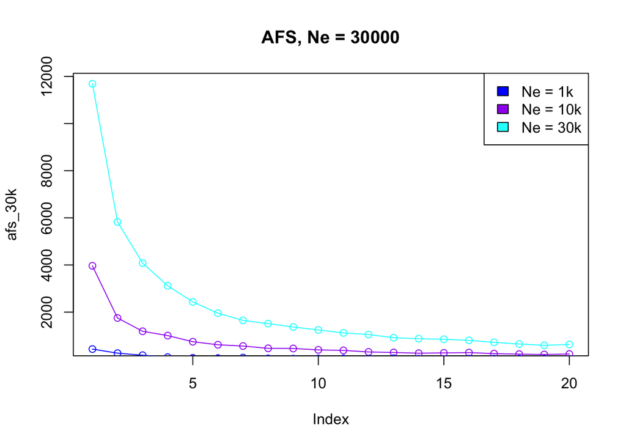

```r
# An R function can be understood as a block of a computer program which executes
# a block of code inside the {...} brackets given a certain value of a parameter
# (here 'Ne' just after the word 'function')
simulate_afs <- function(Ne) {
  # create a slendr model with a single population of size Ne = N
  pop <- population("pop", N = Ne, time = 1)
  model <- compile_model(pop, generation_time = 1, simulation_length = 100000)

  # simulate a tree sequence
  ts <-
    msprime(model, sequence_length = 10e6, recombination_rate = 1e-8) %>%
    ts_mutate(mutation_rate = 1e-8)

  # get a random sample of names of 10 individuals
  samples <- ts_names(ts) %>% sample(10)

  # compute the AFS vector (dropping the 0-th element added by tskit)
  afs <- ts_afs(ts, sample_sets = list(samples))[-1]

  afs
}

# Let's use our custom function to simulate AFS vector for Ne = 1k, 10k, and 30k
afs_1k <- simulate_afs(1000)
afs_10k <- simulate_afs(10000)
afs_30k <- simulate_afs(30000)

# Plot the three simulated AFS using base R plotting functionality
plot(afs_30k, type = "o", main = "AFS, Ne = 30000", col = "cyan",)
lines(afs_10k, type = "o", main = "AFS, Ne = 10000", col = "purple")
lines(afs_1k, type = "o", main = "AFS, Ne = 1000", col = "blue")
legend("topright", legend = c("Ne = 1k", "Ne = 10k", "Ne = 30k"),
       fill = c("blue", "purple", "cyan"))
```

## Part 2: Estimating unknown $N_e$ from empirical AFS

Imagine you sequenced 10 samples from a population and computed the following AFS vector (which contains, sequentially, the number of singletons, doubletons, etc., in your sample from a population):

```r
afs_observed <- c(2520, 1449, 855, 622, 530, 446, 365, 334, 349, 244,
                  264, 218,  133, 173, 159, 142, 167, 129, 125, 143)
```

You know (maybe from some fossil evidence) that the population probably had a constant $N_e$ somewhere between 1000 and 30000 for the past 100,000 generations, and had mutation and recombination rates of 1e-8 (i.e., parameters already implemented by your `simulate_afs()` function).

**Use *slendr* simulations to guess the true (and hidden!) $N_e$ given the observed AFS by running simulations for a range of $N_e$ values and finding out which $N_e$ produces the closest AFS vector to the `afs_observed` vector above using one of the following two approaches.**

- **Option 1** [easy]: Plot AFS vectors for various $N_e$ values, then eyeball which looks closest to the observed AFS based on the figures alone. (This is, of course, not how proper statistical inference is done, but it will be good enough for this exercie!)
- **Option 2** [hard]: Simulate AFS vectors in steps of possible `Ne` (maybe `lapply()`?), and find the $N_e$ which gives the closest AFS to the observed AFS based on [Mean squared error](https://en.wikipedia.org/wiki/Mean_squared_error).

**Click to see the solution to “Option 1”**

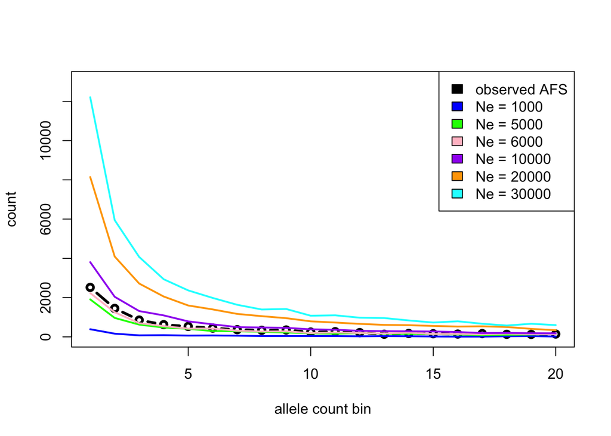

```r
# This is our starting observed AFS which we want to compare simulated AFS vectors to
afs_observed <- c(2520, 1449, 855, 622, 530, 446, 365, 334, 349, 244,
                  264, 218,  133, 173, 159, 142, 167, 129, 125, 143)

# We know that the Ne is between 1000 and 30000, so let's simulate
# a bunch of AFS vectors for different Ne values using our custom
# AFS simulation function
afs_Ne1k <- simulate_afs(Ne = 1000)
afs_Ne5k <- simulate_afs(Ne = 5000)
afs_Ne6k <- simulate_afs(Ne = 6000)
afs_Ne10k <- simulate_afs(Ne = 10000)
afs_Ne20k <- simulate_afs(Ne = 20000)
afs_Ne30k <- simulate_afs(Ne = 30000)

# Plot all simulated AFS vectors, highlighting the observed AFS in black
plot(afs_observed, type = "b", col = "black", lwd = 3,
     xlab = "allele count bin", ylab = "count", ylim = c(0, 13000))
lines(afs_Ne1k, lwd = 2, col = "blue")
lines(afs_Ne5k, lwd = 2, col = "green")
lines(afs_Ne6k, lwd = 2, col = "pink")
lines(afs_Ne10k, lwd = 2, col = "purple")
lines(afs_Ne20k, lwd = 2, col = "orange")
lines(afs_Ne30k, lwd = 2, col = "cyan")
legend("topright",
       legend = c("observed AFS", "Ne = 1000", "Ne = 5000",
                  "Ne = 6000", "Ne = 10000", "Ne = 20000", "Ne = 30000"),
       fill = c("black", "blue", "green", "pink", "purple", "orange", "cyan"))
```

```r
# !!!!! SPOILER ALERT BEFORE REVEALING THE CORRECT ANSWER !!!!!
#
#
#
#
#
#
#
#
#
#
#
#
#
#
#
#
#
#
#
#
#
#
#
#
#
#
#
#
#
#
#
#
#
#
#
#
#
#
#
#
#
#
#
#
#
#
#
# true Ne was 6543!
```

**Click to see the solution to “Option 2”**

```r
# This is our starting observed AFS which we want to compare simulated AFS vectors to
afs_observed <- c(2520, 1449, 855, 622, 530, 446, 365, 334, 349, 244,
                  264, 218,  133, 173, 159, 142, 167, 129, 125, 143)

# Generate regularly spaced values of potential Ne values (our parameter grid)
Ne_grid <- seq(from = 1000, to = 30000, by = 500)
Ne_grid

# I'm not entirely sure if your workshop cloud instances support big
# parallelization runs -- if not, you can modify the `mc.cores =` argument
# a couple of lines below to a smaller number (`mc.cores = 1` would make
# the simulation run on a single processor, i.e. no parallelization).
library(parallel)

# Compute AFS (in parallel, to make things faster) across the entire grid of possible Ne values
afs_grid <- mclapply(Ne_grid, simulate_afs, mc.cores = detectCores())
names(afs_grid) <- Ne_grid

# Show the first five simulated AFS vectors, for brevity
afs_grid[1:5]



# Plot the observed AFS...
plot(afs_observed, type = "b", col = "black", lwd = 3, xlab = "allele count bin", ylab = "count")
# ... and overlay the simulated AFS vectors on top of it
for (i in seq_along(Ne_grid)) {
  lines(afs_grid[[i]], lwd = 0.5)
}
legend("topright", legend = c("observed AFS", "simulated AFS"), fill = c("black", "gray"))




# Compute mean-squared error of the AFS produced by each Ne value across the grid
errors <- sapply(afs_grid, function(sim_afs) {
  sum((sim_afs - afs_observed)^2) / length(sim_afs)
})

plot(Ne_grid, errors, ylab = "error")
abline(v = Ne_grid[which.min(errors)], col = "red")
legend("topright", legend = paste("minimum error Ne =", Ne_grid[which.min(errors)]), fill = "red")




# Plot the AFS again, but this time highlight the most likely spectrum
# (i.e. the one which gave the lowest RMSE value)
plot(afs_observed, type = "b", col = "black", lwd = 3, xlab = "allele count bin", ylab = "count")
for (i in seq_along(Ne_grid)) {
  color <- if (i == which.min(errors)) "red" else "gray"
  width <- if (i == which.min(errors)) 2 else 0.75
  lines(afs_grid[[i]], lwd = width, col = color)
}
legend("topright", legend = c("observed AFS", paste("best fitting Ne =", Ne_grid[which.min(errors)])),
       fill = c("black", "red"))


# !!!!! SPOILER ALERT BEFORE REVEALING THE CORRECT ANSWER !!!!!
#
#
#
#
#
#
#
#
#
#
#
#
#
#
#
#
#
#
#
#
#
#
#
#
#
#
#
#
#
#
#
#
#
#
#
#
#
#
#
#
#
#
#
#
#
#
#
# true Ne was 6543!
```

# Exercise 4: Simulating dynamics of positive selection

The primary motivation for designing *slendr* was to make demographic modelling in R as trivially easy and fast as possible, focusing exclusively on neutral models. However, as *slendr* became popular, people have been asking for the possibility of simulating natural selection. After all, a large part of *slendr*’s functionality deals with population genetic [models across geographical landscapes](https://www.slendr.net/articles/vignette-06-locations.html), which requires SLiM. So why not support selection simulations using *slendr* as well?

In December 2024 I caved in and added support for modifying *slendr* demographic models with bits of SLiM code, which allows simulating pretty much any arbitrary selection scenario you might be interested in.

This exercise is a quick demonstration of how this works and how you might simulate selection using *slendr*. We will do this using another toy model of ancient human history, which we will first use as a basis for simulating the frequency trajectory of an allele under positive selection, and then implementing a toy selection scan summary statistic using Tajima’s D.

To speed things up, **create a new `exercise4.R` script and copy the following code as a starting point for this exercise**:

```r
library(slendr)
init_env(quiet = TRUE)

# This line sources a script in which I provide a few useful helper functions
# which you can use in this exercise
source(here::here("utils.R"))

# African ancestral population
afr <- population("AFR", time = 65000, N = 5000)

# First migrants out of Africa
ooa <- population("OOA", parent = afr, time = 60000, N = 5000, remove = 27000)

# Eastern hunter-gatherers
ehg <- population("EHG", parent = ooa, time = 28000, N = 5000, remove = 6000)

# European population
eur <- population("EUR", parent = ehg, time = 25000, N = 5000)

# Anatolian farmers
ana <- population("ANA", time = 28000, N = 5000, parent = ooa, remove = 4000)

# Yamnaya steppe population
yam <- population("YAM", time = 8000, N = 5000, parent = ehg, remove = 2500)

# Define gene-flow events
gf <- list(
  gene_flow(from = ana, to = yam, rate = 0.75, start = 7500, end = 6000),
  gene_flow(from = ana, to = eur, rate = 0.5, start = 6000, end = 5000),
  gene_flow(from = yam, to = eur, rate = 0.6, start = 4000, end = 3500)
)

# Compile all populations into a single slendr model object
model <- compile_model(
  populations = list(afr, ooa, ehg, eur, ana, yam),
  gene_flow = gf, generation_time = 30
)

# Schedule the sampling from four European populations roughly before their
# disappearance (or before the end of the simulation)
schedule <- rbind(
  schedule_sampling(model, times = 0, list(eur, 50)),
  schedule_sampling(model, times = 6000, list(ehg, 50)),
  schedule_sampling(model, times = 4000, list(ana, 50)),
  schedule_sampling(model, times = 2500, list(yam, 50))
)
```

**Next, visualize the demographic model.** If you did a bit of work in human population genetics, you might recognize it as a very simplified model of demographic history of Europe over the past 50 thousand years or so. As you can see, we are recording 50 individuals from four populations – for Europeans we sample 50 individuals at “present-day”, for the remaining populations we’re recording 50 individuals just before their disappearance. Also note that there’s quite a bit of gene-flow! This was an important thing we’ve learned about human history in the past 10 years or so – everyone is mixed with pretty much everyone, there isn’t (and never was) anything as a “pure population”.

**Note:** We didn’t discuss it earlier, but *slendr* also provides the option to specify a `remove =` argument in a `population()` call which instructs the simulation engine to delete a population from a simulation at a given point. For our `msprime()` simulations in earlier examples it wasn’t really important, but for the `slim()` simulation we will be running below, we want to make a population extinct at a certain timepoint. Which is why our ancient populations in the starting script model have the `remove =` parameter specified.

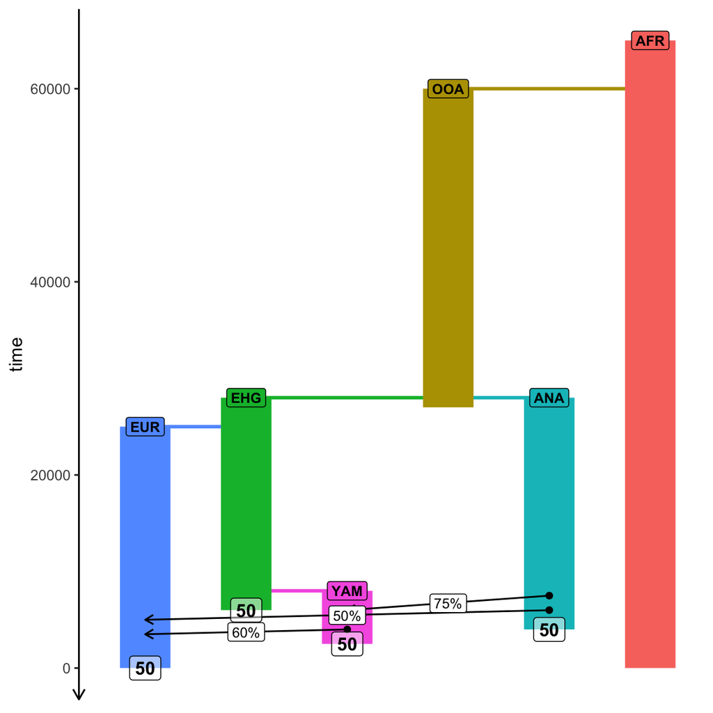

```r
plot_model(model, proportions = TRUE, samples = schedule)
```

### Part 1: Simulating a tree sequence and computing Tajima’s D

Although the point of this exercise is to simulate selection, let’s first simulate a normal neutral model using slendr’s `msprime()` engine as a sanity check. **Simulate 10 Mb of sequence with a recombination rate `1e-8` and a sampling `schedule` defined above.** Let’s not worry about adding any mutations, just to change things up a little bit. We’ll be working with branch-based statistics here (which means adding `mode = "branch"` whenever we will be computing a statistic, such as Tajima’s D).

**Click to see the solution**

```r
ts <- msprime(model, sequence_length = 10e6, recombination_rate = 1e-8, samples = schedule)

ts # no mutations!
```

```
╔═══════════════════════════╗
║TreeSequence               ║
╠═══════════════╤═══════════╣
║Trees          │      19166║
╟───────────────┼───────────╢
║Sequence Length│   10000000║
╟───────────────┼───────────╢
║Time Units     │generations║
╟───────────────┼───────────╢
║Sample Nodes   │        400║
╟───────────────┼───────────╢
║Total Size     │    3.8 MiB║
╚═══════════════╧═══════════╝
╔═══════════╤═════╤═════════╤════════════╗
║Table      │Rows │Size     │Has Metadata║
╠═══════════╪═════╪═════════╪════════════╣
║Edges      │82578│  2.5 MiB│          No║
╟───────────┼─────┼─────────┼────────────╢
║Individuals│  200│  5.5 KiB│          No║
╟───────────┼─────┼─────────┼────────────╢
║Migrations │    0│  8 Bytes│          No║
╟───────────┼─────┼─────────┼────────────╢
║Mutations  │    0│ 16 Bytes│          No║
╟───────────┼─────┼─────────┼────────────╢
║Nodes      │22275│609.1 KiB│          No║
╟───────────┼─────┼─────────┼────────────╢
║Populations│    6│417 Bytes│         Yes║
╟───────────┼─────┼─────────┼────────────╢
║Provenances│    1│  3.6 KiB│          No║
╟───────────┼─────┼─────────┼────────────╢
║Sites      │    0│ 16 Bytes│          No║
╚═══════════╧═════╧═════════╧════════════╝
```

**Inspect the table of all individuals recorded in our tree sequence using the function `ts_samples()`, making sure we have all the individuals scheduled for tree-sequence recording.** (Again, there’s no such a thing as too many sanity checks when doing research!)

**Click to see the solution**

```r
ts_samples(ts)
```

```
# A tibble: 200 × 3
   name    time pop
   <chr>  <dbl> <chr>
 1 EHG_1   6000 EHG
 2 EHG_2   6000 EHG
 3 EHG_3   6000 EHG
 4 EHG_4   6000 EHG
 5 EHG_5   6000 EHG
 6 EHG_6   6000 EHG
 7 EHG_7   6000 EHG
 8 EHG_8   6000 EHG
 9 EHG_9   6000 EHG
10 EHG_10  6000 EHG
# ℹ 190 more rows
```

```r
library(dplyr)
ts_samples(ts) %>% group_by(pop, time) %>% tally
```

```
# A tibble: 4 × 3
# Groups:   pop [4]
  pop    time     n
  <chr> <dbl> <int>
1 ANA    4000    50
2 EHG    6000    50
3 EUR       0    50
4 YAM    2500    50
```

As you’ve already learned in an earlier exercise, *tskit* functions in *slendr* generally operate on vectors (or lists) of individual names, like those produced by `ts_names()` above. **Get a vector of names of individuals in every population recorded in the tree sequence, then use this to compute Tajima’s D using the *slendr* function `ts_tajima()`.** (Use the same approach as you have with `ts_diversity()` or `ts_divergence()` above, using the list of names of individuals as the `sample_sets =` argument for `ts_tajima()`). **Do you see any striking differences in the Tajima’s D values across populations? Check [this](https://en.wikipedia.org/wiki/Tajima%27s_D#Interpreting_Tajima's_D) for some general guidance.**

**Click to see the solution**

```r
samples <- ts_names(ts, split = "pop")
samples
```

```
$ANA
 [1] "ANA_1"  "ANA_2"  "ANA_3"  "ANA_4"  "ANA_5"  "ANA_6"  "ANA_7"  "ANA_8"
 [9] "ANA_9"  "ANA_10" "ANA_11" "ANA_12" "ANA_13" "ANA_14" "ANA_15" "ANA_16"
[17] "ANA_17" "ANA_18" "ANA_19" "ANA_20" "ANA_21" "ANA_22" "ANA_23" "ANA_24"
[25] "ANA_25" "ANA_26" "ANA_27" "ANA_28" "ANA_29" "ANA_30" "ANA_31" "ANA_32"
[33] "ANA_33" "ANA_34" "ANA_35" "ANA_36" "ANA_37" "ANA_38" "ANA_39" "ANA_40"
[41] "ANA_41" "ANA_42" "ANA_43" "ANA_44" "ANA_45" "ANA_46" "ANA_47" "ANA_48"
[49] "ANA_49" "ANA_50"

$EHG
 [1] "EHG_1"  "EHG_2"  "EHG_3"  "EHG_4"  "EHG_5"  "EHG_6"  "EHG_7"  "EHG_8"
 [9] "EHG_9"  "EHG_10" "EHG_11" "EHG_12" "EHG_13" "EHG_14" "EHG_15" "EHG_16"
[17] "EHG_17" "EHG_18" "EHG_19" "EHG_20" "EHG_21" "EHG_22" "EHG_23" "EHG_24"
[25] "EHG_25" "EHG_26" "EHG_27" "EHG_28" "EHG_29" "EHG_30" "EHG_31" "EHG_32"
[33] "EHG_33" "EHG_34" "EHG_35" "EHG_36" "EHG_37" "EHG_38" "EHG_39" "EHG_40"
```

[output cut: 20 more lines]

```r
# Compute genome-wide Tajima's D for each population -- note that we don't
# expect to see any significant differences because no population experienced
# natural selection (yet)
ts_tajima(ts, sample_sets = samples, mode = "branch")
```

```
# A tibble: 4 × 2
  set         D
  <chr>   <dbl>
1 ANA   -0.0206
2 EHG   -0.111
3 EUR   -0.484
4 YAM   -0.356
```

## Part 2: Computing Tajima’s D in windows

Let’s take this one step forward. Even if there is a locus under positive selection somewhere along our chromosome, it might be quite unlikely that we would find a Tajima’s D value significant enough for the entire chromosome (which is basically what we did in Part 1 now). Fortunately, thanks to the flexibility of the *tskit* module, the *slendr* function `ts_tajima()` has an argument `windows =`, which allows us to specify the coordinates of windows into which a sequence should be broken into, with Tajima’s D computed separately for each window. Perhaps this will allow us to see the impact of positive selection after we get to adding selection to our model. So let’s first built some code towards that.

**Define a variable `windows` which will contain a vector of coordinates of 100 windows, starting at position `0`, and ending at position `10e6` (i.e., the end of our chromosome). Then provide this variable as the `windows =` argument of `ts_tajima()` on a new, separate line of your script. Save the result of `ts_tajima()` into the variable `tajima_wins`, and inspect its contents in the R console.**

**Hint:** You can use the R function `seq()` and its argument `length.out = 100`, to create the coordinates of window boundaries very easily.

**Click to see the solution**

```r
# Pre-compute genomic windows for window-based computation of Tajima's D
windows <- round(seq(0, ts$sequence_length, length.out = 100))
windows
```

```
  [1]        0   101010   202020   303030   404040   505051   606061   707071
  [9]   808081   909091  1010101  1111111  1212121  1313131  1414141  1515152
 [17]  1616162  1717172  1818182  1919192  2020202  2121212  2222222  2323232
 [25]  2424242  2525253  2626263  2727273  2828283  2929293  3030303  3131313
 [33]  3232323  3333333  3434343  3535354  3636364  3737374  3838384  3939394
 [41]  4040404  4141414  4242424  4343434  4444444  4545455  4646465  4747475
 [49]  4848485  4949495  5050505  5151515  5252525  5353535  5454545  5555556
 [57]  5656566  5757576  5858586  5959596  6060606  6161616  6262626  6363636
 [65]  6464646  6565657  6666667  6767677  6868687  6969697  7070707  7171717
 [73]  7272727  7373737  7474747  7575758  7676768  7777778  7878788  7979798
 [81]  8080808  8181818  8282828  8383838  8484848  8585859  8686869  8787879
 [89]  8888889  8989899  9090909  9191919  9292929  9393939  9494949  9595960
 [97]  9696970  9797980  9898990 10000000
```

```r
# Compute genome-wide Tajima's D for each population in individual windows
tajima_wins <- ts_tajima(ts, sample_sets = samples, windows = windows, mode = "branch")
tajima_wins
```

```
# A tibble: 4 × 2
  set   D
  <chr> <named list>
1 ANA   <dbl [99]>
2 EHG   <dbl [99]>
3 EUR   <dbl [99]>
4 YAM   <dbl [99]>
```

```r
# You can see that the format of the result is slightly strange, with the
# `D` column containing a vector of numbers (this is done for conciseness)
tajima_wins[1, ]$D
```

```
$`1`
 [1]  0.322586241 -1.131590669  0.145885670  0.258461314 -0.336153816
 [6] -0.600313052  0.076810562 -0.568552283 -0.615982133 -1.083849025
[11] -0.901546033 -0.911852068  0.197844582 -0.205690764 -0.913144419
[16]  0.272065892  0.904329617  0.676885450 -0.360091724 -0.637492580
[21] -0.959459372 -0.110982779 -0.321297195 -0.662488403 -0.462468822
[26] -0.279088041 -0.144678880 -0.496910359  0.060028918 -0.200632423
[31] -0.453740629  0.585412541  0.519734308  0.139719863  0.355920166
[36] -0.548111583 -0.208779329  0.097755401 -0.038327126 -0.403066797
[41] -0.233498138 -0.775016143 -0.821464112  0.251868055 -0.023335358
[46]  0.083382647  0.669201651  0.921764737  0.137072979  0.044794709
[51]  0.618447199 -0.606448151 -0.684065857  0.103085828  0.215428528
[56]  0.568889424  0.643145588  0.213250938  0.335898515 -0.332092371
[61]  0.819375337  0.331247783  0.258706950  0.010228840 -0.317729430
[66] -0.414557898  0.103969355  0.167502068  0.108271828 -0.220301742
[71]  0.516613542 -0.721743451 -0.165234564 -0.338057235 -0.359236093
[76] -0.305923002  0.314102626 -0.173345903  0.046910937  0.094613924
[81]  0.357761277  0.426801216 -0.298805177  0.376999874  0.415943483
[86]  0.322976561 -0.003130940 -0.205264236  0.289125415  0.101734098
[91]  0.192415170 -0.183248559 -0.098833557  0.323755411  0.131100638
[96]  0.007048363  0.320005072  0.594374329  0.766607805
```

The default output format of `ts_tajima()` is not super user-friendly. **Process the result using a helper function `process_tajima(tajima_wins)` that I provided for you (perhaps save it as `tajima_df`), and visualize it using another of my helper functions `plot_tajima(tajima_df)`.**

**Note:** Making the `process_tajima()` and `plot_tajima()` function available in your R code is the purpose of the `source(here::here("utils.R"))` command at the beginning of your script for this exercise.

**Click to see the solution**

```r
# The helper function `process_tajima()` reformats the results into a normal
# data frame, this time with a new column `window` which indicates the index
# of the window that each `D` value was computed in
tajima_df <- process_tajima(tajima_wins)
tajima_df
```

```
# A tibble: 396 × 3
   set         D window
   <chr>   <dbl>  <int>
 1 ANA    0.323       1
 2 ANA   -1.13        2
 3 ANA    0.146       3
 4 ANA    0.258       4
 5 ANA   -0.336       5
 6 ANA   -0.600       6
 7 ANA    0.0768      7
 8 ANA   -0.569       8
 9 ANA   -0.616       9
10 ANA   -1.08       10
# ℹ 386 more rows
```

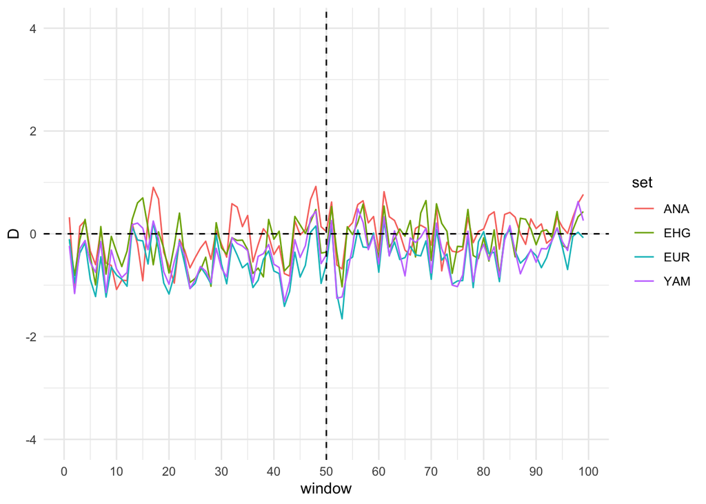

```r
# Now let's visualize the window-based Tajima's D along the simulated genome
# using another helper function `plot_tajima()`
plot_tajima(tajima_df)
```

It’s no surprise that we don’t see any Tajima’s D outliers in any of our windows, because we’re still working with a tree sequence produced by our a purely neutral simulation. But we have everything set up for the next part, in which we will add selection acting on a beneficial allele.

## Part 3: Adding positive selection to the base demographic model

Although primarily designed for neutral demographic models, *slendr* allows optional simulation of natural selection by providing a “SLiM extension code snippet” with customization SLiM code as an optional argument `extension =` of `compile_model()` (a function you’re closely familiar with at this point).

Unfortunately we don’t have any space to explain SLiM here (and I have no idea, at the time of writing, whether or not you will have worked with SLiM earlier in this workshop). Suffice to say that SLiM is another very popular population genetic simulator software which allows simulation of selection, and which requires you to write custom code in a different programming language called Eidos.

**Take a look at the file `slim_extension.txt` provided in your working directory (it’s also part of the GitHub repository [here](https://github.com/bodkan/cesky-krumlov-2025/blob/main/slim_extension.txt)). If you worked with SLiM before, glance through the script casually and see if it makes any sense to you. If you have not worked with SLiM before, look for the strange `{elements}` in curly brackets in the first ten lines of the script.** Those are the parameters of the selection model we will be customizing are standard neutral demographic model from in the next step.

Specifically, when you inspect the `slim_extension.txt` file, you can see that this “SLiM extension script” I provided for you has three parameters:

- `origin_pop` – in which population should a beneficial allele appear,
- `s` – what should be the selection coefficient of the beneficial allele, and
- `onset_time` – at which time should the allele appear in the `origin_pop`.

However, at the start, the SLiM extension snippet doesn’t contain any concrete values of those parameters, but only their `{origin_pop}`, `{s}`, and `{onset_time}` placeholders.

**Use the *slendr* function `substitute_values()` to substitute concrete values for those parameters like this:**

```r
extension <- substitute_values(
  template = here::here("slim_extension.txt"),
  origin_pop = "EUR",
  s = 0.15,
  onset_time = 12000
)
extension
```

```
[1] "/var/folders/70/b_q2zdh116b9pfg29p03sx600000gn/T//RtmpxBNL44/fileb6c74465a16"
```

You can see that `substitute_values()` returned a path to a file. **Take a look at that file in your terminal – you should see each of the three `{placeholder}` parameters replaced with a concrete given value.**

**Click to see the solution**

Let’s take a look at the first 15 lines of the extension file before and after calling `substitute_values()`. We’ll do this in R for simplicity, but you can use `less` in plain unix terminal.

**Before – see the {{placeholder}} parameters in their original form:**

```
// Define model constants (to be substituted) all in one place
// (each {{placeholder}} will be replaced by a value passed from R).
// Note that string constant template patterns are surrounded by "quotes"!
initialize() {
    defineConstant("s", {{s}});
    defineConstant("onset_time", {{onset_time}});
    defineConstant("origin_pop", "{{origin_pop}}");

    // compose a trajectory file based on given parameters
    defineConstant("traj_file", PATH + "/" + "trajectory.tsv");
}
```

**After – see the {{placeholder}} parameters with concrete values!**

```
// Define model constants (to be substituted) all in one place
// (each {{placeholder}} will be replaced by a value passed from R).
// Note that string constant template patterns are surrounded by "quotes"!
initialize() {
    defineConstant("s", 0.15);
    defineConstant("onset_time", 12000);
    defineConstant("origin_pop", "EUR");

    // compose a trajectory file based on given parameters
    defineConstant("traj_file", PATH + "/" + "trajectory.tsv");
}
```

And that’s all the extra work we need to turn our purely neutral demographic *slendr* model into a model which includes natural selection! (In this case, only a simple selection acting on a single locus, as you’ll see later, but this can be generalized to any imaginable selection scenario.)

How do we use the SLiM extension for our simulation? It’s very simple – we just have to provide the `extension` variable as an additional argument of good old `compile_model()`. This will compile a new *slendr* model which will now include the new functionality for simulating natural selection:

**Compile a new `model` of the history of populations `afr`, `ooa`, `ehg`, etc., by following the instructions above, providing a new `extension =` argument to the `compile_model()` function.**

**Click to see the solution**

```r
model <- compile_model(
  populations = list(afr, ooa, ehg, eur, ana, yam),
  gene_flow = gf, generation_time = 30,
  extension = extension   # <======== this is missing in the neutral example!
)
```

## Part 4: Running a selection simulation using `slim()`

Now we can finally run our selection simulation!

There are two modifications to our previous simulation workflows:

1. Because we need to run a non-neutral simulation, we have to switch from using the `msprime()` *slendr* engine to `slim()`. The latter can still interpret the same demographic model we programmed in R, just like the `msprime()` engine can, but will run the model using SLiM (and thus leveraging the new SLiM extension code that we have customized using `substitute_values()` above). We simply do this by switching from this:

```r
ts <- msprime(model, sequence_length = 10e6, recombination_rate = 1e-8, samples = schedule)
```

to this:

```r
ts <- slim(model, sequence_length = 10e6, recombination_rate = 1e-8, samples = schedule)
```

As you can see, you don’t have to modify anything in your model code, just switching from `msprime` to `slim` in the line of code which produces the simulation result.

2. The customized model will not only produce a tree sequence, but will also generate a table of allele frequencies in each population (SLiM experts might have noticed the revelant SLiM code when they were inspecting [`slim_extension.txt`](https://github.com/bodkan/cesky-krumlov-2025/blob/main/slim_extension.txt)). We need to be able to load both of these files after the simulation and thus need a path to a location we can find those files. We can do this by calling the `slim()` function as `path <- slim(..., path = TRUE)` (so with the extra `path =` argument). This will return a path to where the `slim()` engine saved all files with our desired results.

**Run a simulation from the modified model of selection with the `slim()` engine as instructed in points number 1. and 2. above, then use the `list.files(path)` function in R to take a look in the directory. Which files were produced by the simulation?**

**Click to see the solution (you have a working SLiM installation)**

```r
# tstart <- Sys.time()
path <- slim(model, sequence_length = 10e6, recombination_rate = 1e-8, samples = schedule, path = TRUE, random_seed = 59879916)
# tend <- Sys.time()
# tend - tstart # Time difference of 38.82014 secs

# We can verify that the path not only contains a tree-sequence file but also
# the table of allele frequencies.
list.files(path)
```

**Click to see the solution (you don’t have a working SLiM installation *or* the simulation takes too long)**

```r
# If you don't have SLiM set up, just use the simulated results from my own
# run of the same simulation
path <- here::here("data/selection")

# We can verify that the path not only contains a tree-sequence file but also
# the table of allele frequencies.
list.files(path)
```

```
[1] "slim.trees"     "trajectory.tsv"
```

## Part 5: Investigating allele frequency trajectories

**Use another helper function `read_trajectory(path)` which I provided for this exercise to read the simulated frequency trajectories of the positively selected mutation in all of our populations into a variable `traj_df`. Then run a second helper function `plot_trajectory(traj_df)` to inspect the trajectories visually.**

**Click to see the solution**

```r
traj_df <- read_trajectory(path)
traj_df
```

```
# A tibble: 1,604 × 4
    time pop      freq onset
   <dbl> <fct>   <dbl> <dbl>
 1 11990 EHG    0      12000
 2 11990 ANA    0      12000
 3 11990 EUR    0.0001 12000
 4 11990 YAM   NA      12000
 5 11960 EHG    0      12000
 6 11960 ANA    0      12000
 7 11960 EUR    0.0001 12000
 8 11960 YAM   NA      12000
 9 11930 EHG    0      12000
10 11930 ANA    0      12000
# ℹ 1,594 more rows
```

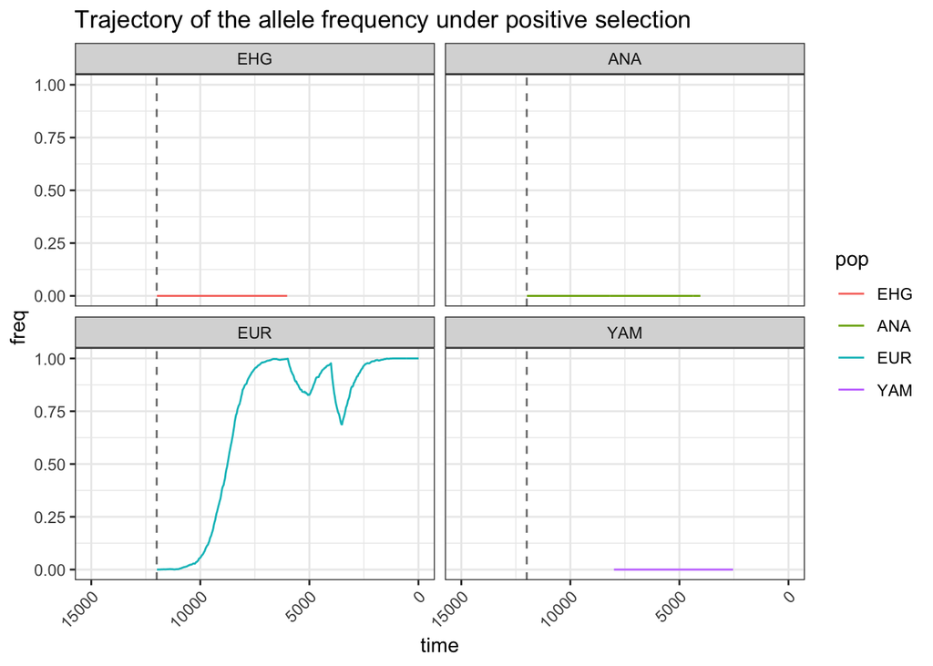

```r
plot_trajectory(traj_df)
```

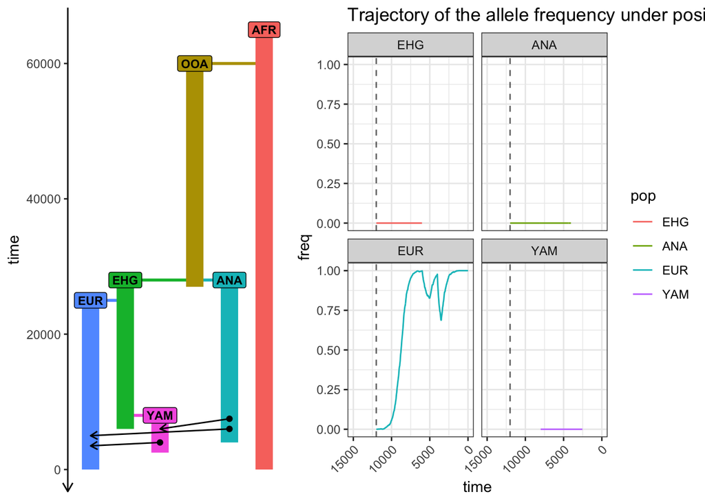

```r
# Comparing the trajectories side-by-side with the demographic model reveals
# some obvious patterns of both selection and demographic history.
plot_grid(
  plot_model(model),
  plot_trajectory(traj_df),
  nrow = 1, rel_widths = c(0.7, 1)
)
```

## Part 6: Tajima’s D (genome-wide and window-based) from the selection model

Recall that your simulation run saved results in the location stored in the `path` variable:

```r
list.files(path)
```

```
[1] "slim.trees"     "trajectory.tsv"
```

From this `path`, we’ve already successfuly investigated the frequency trajectories.

Now let’s compute Tajima’s D on the tree sequence simulated from our selection model. Hopefully we should see an interesting pattern in our selection scan? For instance, we don’t know yet *where* in the genome is the putative locus under selection!

To read a tree sequence simulated with `slim()` by our customized selection setup, we need to do a bit of work. To simplify things a bit, here’s the R code which makes it possible to do. Just copy it in your `exercise4.R` script as it is:

```r
# Let's use my own saved simulation results, so that we're all on the
# same page going forward
path <- here::here("data/selection")

ts <-
  file.path(path, "slim.trees") %>%  # 1. compose full path to the slim.trees file
  ts_read(model) %>%                 # 2. read the tree sequence file into R
  ts_recapitate(Ne = 5000, recombination_rate = 1e-8) # 3. perform recapitation
```

Very briefly, because our tree sequence was generated by SLiM, it’s very likely that not all genealogies along the simulated genome will be fully coalesced (i.e., not all tree will have a single root). To explain why this is the case is out of the scope of this session, but read [here](https://tskit.dev/pyslim/docs/latest/tutorial.html) if you’re interested in learning more. For the time being, it suffices to say that we can pass the (uncoalesced) tree sequence into the `ts_recapitate()` function, which then takes a SLiM tree sequence and simulates all necessary “ancestral history” that was missing on the uncoalesced trees, thus ensuring that the entire tree sequence is fully coalesced and can be correctly computed on.

**Now that you have a `ts` tree sequence object resulting from a new selection simulation run, repeat the analyses of genome-wide and window-based Tajima’s D from *Part 1* and *Part 2* of this exercise, again using the provided helper functions `process_tajima()` and `plot_tajima()`. Can you identify which locus has been the likely focal point of the positive selection? Which population shows evidence of selection? Which doesn’t and why (look again at the visualization of the demographic model above)?**

**Click to see the solution**

```r
samples <- ts_names(ts, split = "pop")
samples
```

```
$ANA
 [1] "ANA_1"  "ANA_2"  "ANA_3"  "ANA_4"  "ANA_5"  "ANA_6"  "ANA_7"  "ANA_8"
 [9] "ANA_9"  "ANA_10" "ANA_11" "ANA_12" "ANA_13" "ANA_14" "ANA_15" "ANA_16"
[17] "ANA_17" "ANA_18" "ANA_19" "ANA_20" "ANA_21" "ANA_22" "ANA_23" "ANA_24"
[25] "ANA_25" "ANA_26" "ANA_27" "ANA_28" "ANA_29" "ANA_30" "ANA_31" "ANA_32"
[33] "ANA_33" "ANA_34" "ANA_35" "ANA_36" "ANA_37" "ANA_38" "ANA_39" "ANA_40"
[41] "ANA_41" "ANA_42" "ANA_43" "ANA_44" "ANA_45" "ANA_46" "ANA_47" "ANA_48"
[49] "ANA_49" "ANA_50"

$EHG
 [1] "EHG_1"  "EHG_2"  "EHG_3"  "EHG_4"  "EHG_5"  "EHG_6"  "EHG_7"  "EHG_8"
 [9] "EHG_9"  "EHG_10" "EHG_11" "EHG_12" "EHG_13" "EHG_14" "EHG_15" "EHG_16"
[17] "EHG_17" "EHG_18" "EHG_19" "EHG_20" "EHG_21" "EHG_22" "EHG_23" "EHG_24"
[25] "EHG_25" "EHG_26" "EHG_27" "EHG_28" "EHG_29" "EHG_30" "EHG_31" "EHG_32"
[33] "EHG_33" "EHG_34" "EHG_35" "EHG_36" "EHG_37" "EHG_38" "EHG_39" "EHG_40"
```

[output cut: 20 more lines]

```r
# Overall Tajima's D across the 10Mb sequence still doesn't reveal any significant
# deviations even in case of selection (again, not entirely unsurprising)
ts_tajima(ts, sample_sets = samples, mode = "branch")
```

```
# A tibble: 4 × 2
  set         D
  <chr>   <dbl>
1 ANA    0.0382
2 EHG    0.0318
3 EUR   -0.324
4 YAM   -0.296
```

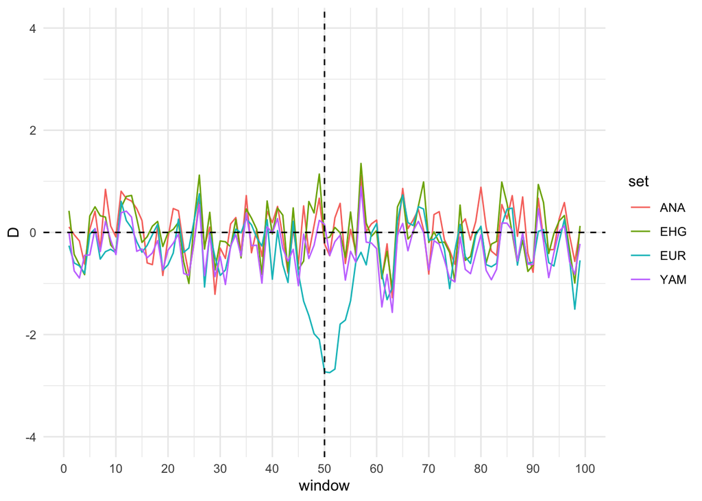

```r
# So let's look at the window-based computation again...
windows <- as.integer(seq(0, ts$sequence_length, length.out = 100))

# compute genome-wide Tajima's D for each population in individual windows
tajima_wins <- ts_tajima(ts, sample_sets = samples, windows = windows, mode = "branch")
tajima_df <- process_tajima(tajima_wins)

plot_tajima(tajima_df)
```

You should see a clear dip in Tajima’s D around the midpoint of the DNA sequence, but only in Europeans. The beneficial allele appeared in the European population, and although the plot of the allele frequency trajectories shows that the selection dynamics has been *dramatically* affected by gene-flow events (generally causing a repeated “dilution” of the selection signal in Europeans), there has never been gene-flow (at least in our model) *from* Europeans to other populations, so the beneficial allele never had a chance to “make it” into those populations.

**Bonus exercises**

#### Bonus 1: Investigate the impact of recombination around the selected locus

Vary the uniform recombination rate and observe what happens with Tajima’s D in windows along the genome.

**Click to see the solution**

Solution: just modify the value of the `recombination_rate =` argument provided to the `slim()` function above.

#### Bonus 2: Simulate origin of the allele in EHG

Simulate the origin of the beneficial allele in the EHG population – what do the trajectories look like now? How does that change the Tajima’s D distribution along the genome in our European populations?

**Click to see the solution**

Use this extension in the `slim()` call, and repeat the rest of the selection-based workflow in this exercise.

```r
extension <- substitute_values(
  template = "slim_extension.txt",
  origin_pop = "EHG",
  s = 0.1,
  onset_time = 12000
)
model <- compile_model(
  populations = list(afr, ooa, ehg, eur, ana, yam),
  gene_flow = gf, generation_time = 30,
  extension = extension
)
```

#### Bonus 3: Other statistics in windows

As a practice of your newly acquired tree-sequence computation skills with *slendr*, calculate some other statistics in the same windows along the simulated genome, visualize them yourself, and compare the results to the window-based Tajima’s D pattern. For instance, `ts_diversity()`, `ts_divergence()`, or `ts_segregating()` might be quite interesting to look at.

**Click to see the solution**

Use the same tree sequence file you’ve computed Tajima’s D on, and then apply the functions `ts_diversity()`, `ts_divergence()`, and `ts_segregating()` on that tree sequence.

# Exercise 5: Programming of your own model

Do you have a favourite model organism or you study another species? **Take some of the most important features of its demographic history and program them as a new *slendr* model.**

**Then, think about some interesting population genetic statistics that you either know from the literature or that you perhaps computed on your own empirical data. Try to compute them on a tree sequence simulated from your model using `msprime()`. Do you get results which are in the ballpark of your expectations?**

**Click to see the solution**

I don’t have a solution, of course! :) But I would be really happy if you send me a *slendr* script with your model, especially if you get to use it in your own projects!

If you would be OK with it, I think it would be great to create a gallery of models created by people for all kinds of different species and publish  
it on the [*slendr* website](https://slendr.net).